# Reproducting analysis in the paper: Sex diversity in proximal tubule and endothelial gene expression in mice with ischemic acute kidney injury

Arvin Zaker

March 14, 2023

# Abstract

This study by Viñas et al.(Viñas et al. 2020) studies the sex-related differences between mice with and without acute kidney injury (AKI) Previous studies have shown that sex differences in mice might influence AKI. To simulate AKI, researchers performed ischemia-reperfusion injury (IRI) assay and studies male and female mice morphologically and gnomically.

The study showed that the upregulation of cytokine, chemokine, and cell-adhesion pathways in male mice after IRI might explain differences in the results.

# Introduction

AKI is a disease associated with adverse outcomes, such as hospitalizaitons, mortality, and development of chronic kidney disease (CKD). AKI does not currently have any therapies. Moreover, the differences between male and female sexes is not well characterized. Viñas et al.(Viñas et al. 2020) thefore analyzed the male and female mice before and after IRI to chracterize the sex differences and potentially find novel pathways that may be invovled in protecting females.

This document contains an analysis of 24 RNA-seq samples under four experimental conditions from the study. This data is obtained form GEO series GSE144622 (Viñas et al. 2020). Raw data is available from NCBI Gene Expression Omnibus (GEO) [accessible here](https://www.ncbi.nlm.nih.gov/geo/query/acc.cgi?acc=GSE144871). Data contains 24 samples with the following properties:

Information of the samples in RNA-Seq data

|  | tissue | condition | gender |
| --- | --- | --- | --- |
| 10_endothelial_sham_female | endothelial | sham | female |
| 11_endothelial_sham_female | endothelial | sham | female |
| 5_endothelial_sham_male | endothelial | sham | male |
| 6_endothelial_sham_male | endothelial | sham | male |
| 9_endothelial_sham_male | endothelial | sham | male |
| 1_endothelial_IRI_female | endothelial | IRI | female |
| 2_endothelial_IRI_female | endothelial | IRI | female |
| 8_endothelial_IRI_female | endothelial | IRI | female |
| 3_endothelial_IRI_male | endothelial | IRI | male |
| 4_endothelial_IRI_male | endothelial | IRI | male |
| 7_endothelial_IRI_male | endothelial | IRI | male |
| 10_tubular_sham_female | tubular | sham | female |
| 11_tubular_sham_female | tubular | sham | female |
| 13_tubular_sham_female | tubular | sham | female |
| 5_tubular_sham_male | tubular | sham | male |
| 6_tubular_sham_male | tubular | sham | male |
| 9_tubular_sham_male | tubular | sham | male |
| 9B_tubular_sham_male | tubular | sham | male |
| 1_tubular_IRI_female | tubular | IRI | female |
| 2_tubular_IRI_female | tubular | IRI | female |
| 8_tubular_IRI_female | tubular | IRI | female |
| 3_tubular_IRI_male | tubular | IRI | male |
| 4_tubular_IRI_male | tubular | IRI | male |
| 7_tubular_IRI_male | tubular | IRI | male |

# Materials and Methods

The document has mimicked the differential expression analysis of the original paper as closely as possible. However, it tries to expand on the analysis and use other methods to further verify the robustness of the results. Notably, we aim to use gene-set enrichment analysis (GSEA) instead of over-representation analysis (ORA) used by the researchers.

In this workbook we would utilize multiple packages:

- `DESeq2` for differential gene expression analysis (Love, Huber, and Anders 2014).
- `apeglm` for log fold change shrinkage (Zhu, Ibrahim, and Love 2019).
- `ComplexHeatmaps` for the heatmaps(Gu, Eils, and Schlesner 2016).
- `fgsea` for GSEA(Korotkevich et al. 2021).

For pathway analysis, as the paper focuses most on GO biological pathways, we would use the dataset from [MSigDBs GO: Gene Ontology gene sets](https://www.gsea-msigdb.org/gsea/msigdb/download_file.jsp?filePath=/msigdb/release/2022.1.Mm/m5.go.v2022.1.Mm.symbols.gmt) We use the gene symbols for GSEA analysis.

## Removing technical replicates

As you may see in the previous figure, the samples of the experiment we have `9_tubular_sham_male` and `9B_tubular_sham_male` samples. These have the description `Sham M PTs rep 3` and `Sham M PTs rep 3B` associated with them and are considered **technical replicates**. Therefore we should remove one of them form the analysis. For this document we remove the replicate with the lowest read count.

Looking at the read count from each of the smaples we get:

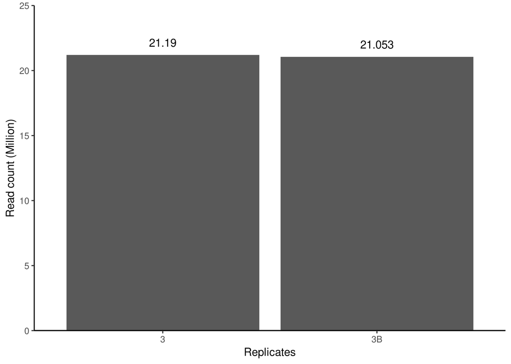

As you may observe both replicates have highly similar read counts so removing one would not affect the analysis significantly. For this analysis, we removed replicate 3B since it has a slightly lower read count.

If we look again at our data we see that we have 23 samples left:

Information of the remaining samples in RNA-Seq data after removal of the technical replicate

|  | tissue | condition | gender |
| --- | --- | --- | --- |
| 10_endothelial_sham_female | endothelial | sham | female |
| 11_endothelial_sham_female | endothelial | sham | female |
| 5_endothelial_sham_male | endothelial | sham | male |
| 6_endothelial_sham_male | endothelial | sham | male |
| 9_endothelial_sham_male | endothelial | sham | male |
| 1_endothelial_IRI_female | endothelial | IRI | female |
| 2_endothelial_IRI_female | endothelial | IRI | female |
| 8_endothelial_IRI_female | endothelial | IRI | female |
| 3_endothelial_IRI_male | endothelial | IRI | male |
| 4_endothelial_IRI_male | endothelial | IRI | male |
| 7_endothelial_IRI_male | endothelial | IRI | male |
| 10_tubular_sham_female | tubular | sham | female |
| 11_tubular_sham_female | tubular | sham | female |
| 13_tubular_sham_female | tubular | sham | female |
| 5_tubular_sham_male | tubular | sham | male |
| 6_tubular_sham_male | tubular | sham | male |
| 9_tubular_sham_male | tubular | sham | male |
| 1_tubular_IRI_female | tubular | IRI | female |
| 2_tubular_IRI_female | tubular | IRI | female |
| 8_tubular_IRI_female | tubular | IRI | female |
| 3_tubular_IRI_male | tubular | IRI | male |
| 4_tubular_IRI_male | tubular | IRI | male |
| 7_tubular_IRI_male | tubular | IRI | male |

# Results

## Sample distributions

### Proximal tubules

In `Figure 3`, authors provide evidence showing that the greatest separation in gene expression is between male and females, followed by the presence of IRI as the second largest factor.

To show this relationship, authors aim to show the variation of gene expression between their samples from endothelial and proximal tubule subsets using principal component analysis (PCA). PCA is calculated using rlog-transformed normalized count values for all transcripts.

If we look at the PCA results from proximal tubules, we can see that the resulting plot perfectly matches the plot seen in the paper:

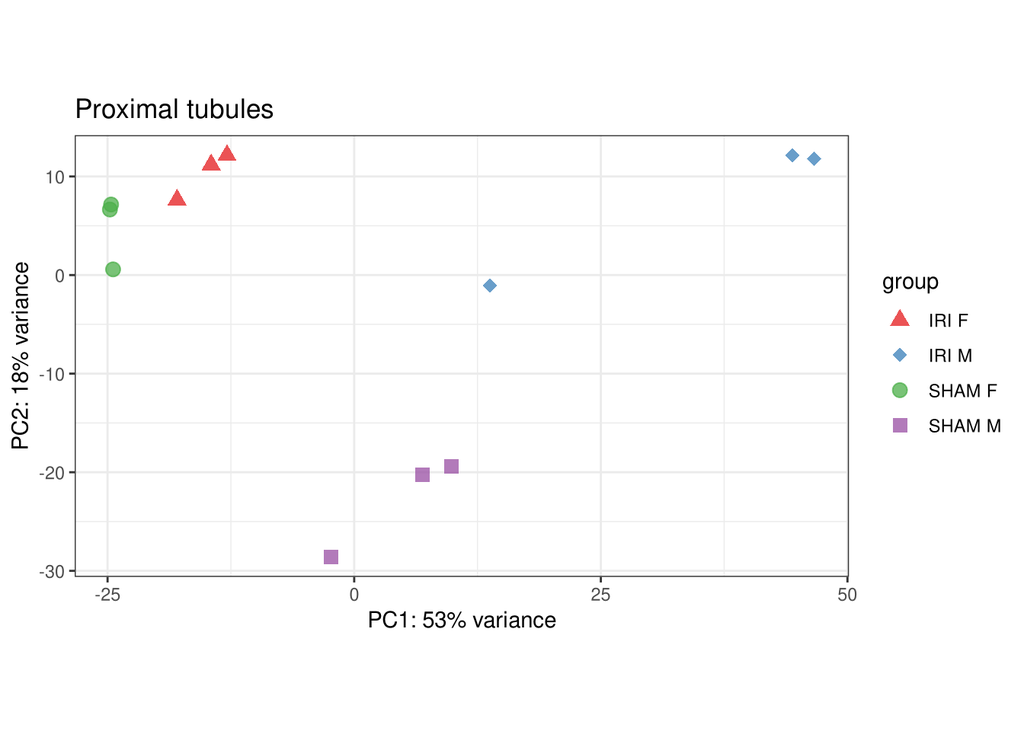

Therefore the PCA plot was reproducible and the results supports the hypothesis that the greatest source of variation is gender (most distinction) followed by treatment.

We can further expand on their analysis by calculating the distance between the rlog-transformed data. We can the visualize the distance of gene expression between samples in a heatmap. Afterwards, we can perform clustering to visualize what samples cluster together.

> Note that we remove the `tubular` part of the name for simplicity.

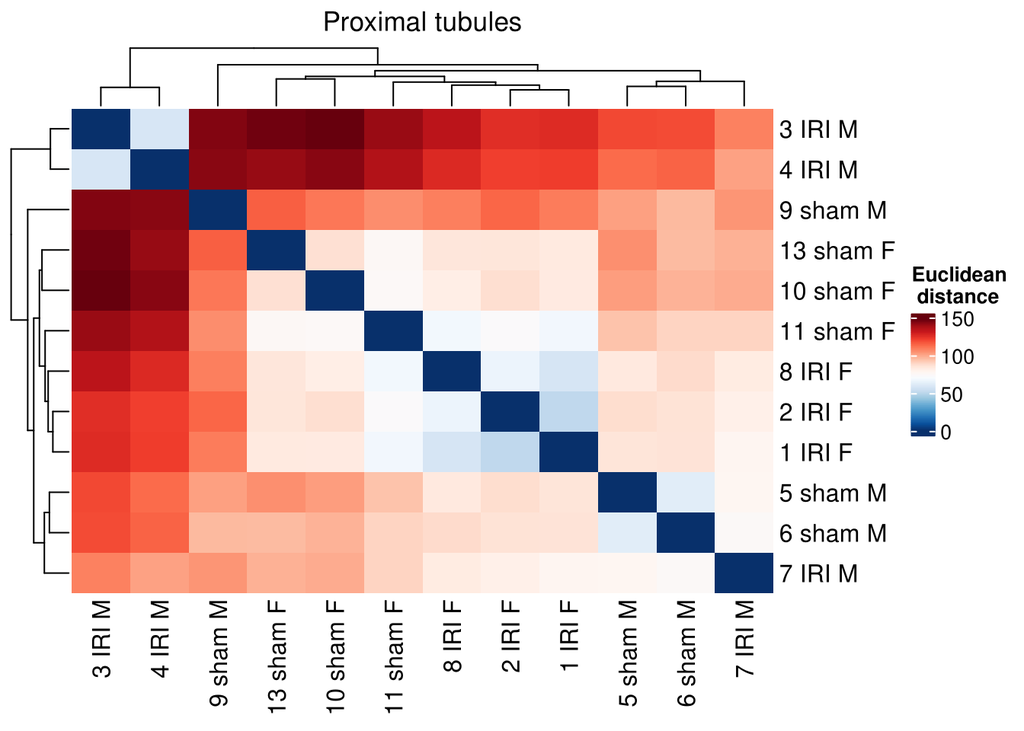

This distance heatmap however, does not fully align with and does not support the results of the experiment. The clustering of the samples does not follow a strict distinction between male or female. However there are two instances where male patients cluster together:

- cluster 1: `5 sham M`, `6 sham M`, `7 IRI M`
- cluster 2: `3 IRI M`, `4 IRI M`

> Note: this results may not support the PCA analysis since PCA is performed using the top 500 most differentially expressed genes.

### Endothelial cells

Next, if we look at the PCA results from endothelial, we can see that the resulting plot perfectly matches the plot seen in the paper:

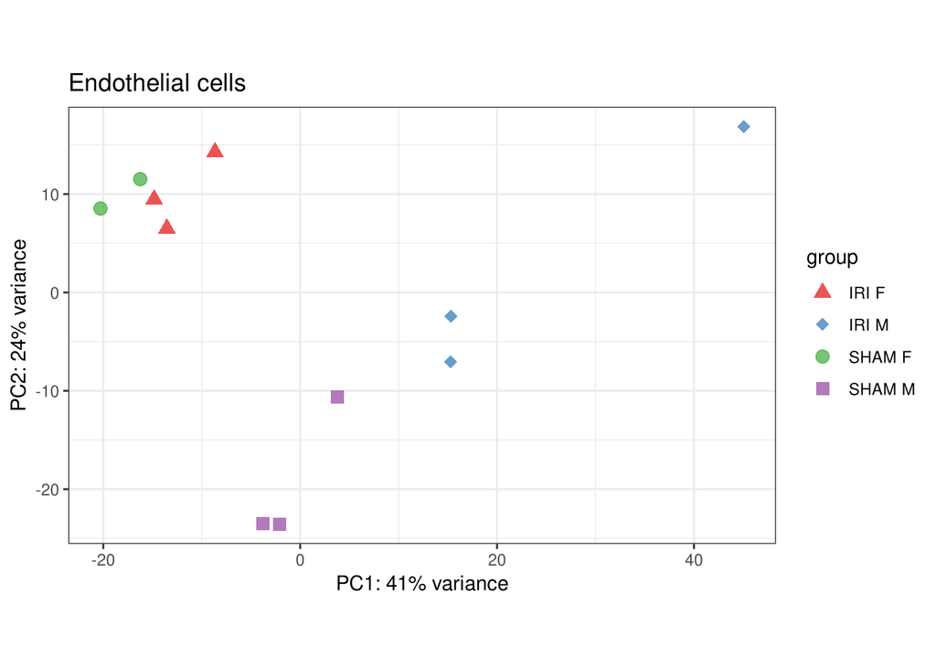

Therefore the PCA plot was reproducible and the results supports the hypothesis that the greatest source of variation is gender (most distinction) followed by treatment. In the case of this PCA analysis, we can see that the effect of treatment is even lower on endothelial cells as compared to proximal tubule cells.

We can further expand on their analysis by calculating the distance and visualizing it in a heatmap with clustering similar to the previous section.

> Note that we remove the `endothelial` part of the name for simplicity.

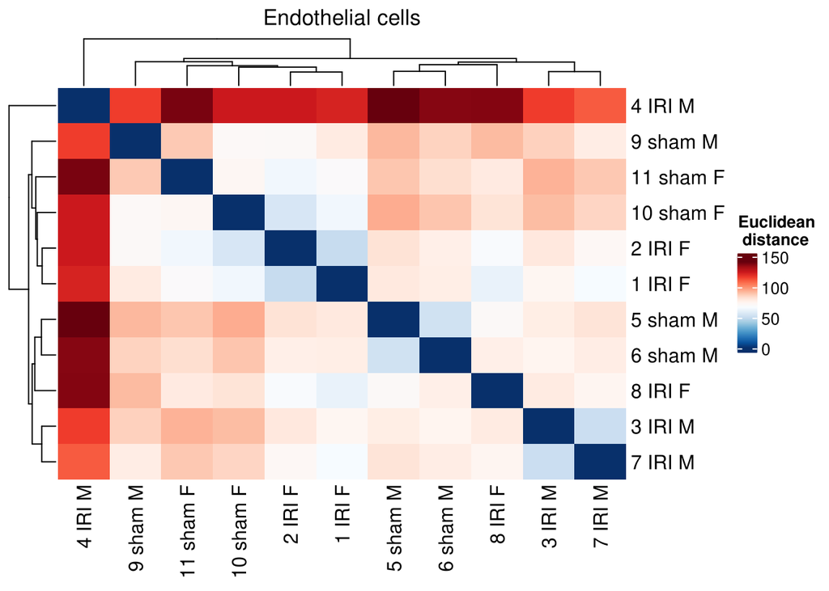

Similar to the previous example, this distance heatmap does not fully align with the results of the experiment. The clustering of the samples does not follow a strict distinction between male or female. However, it can be argued that male samples and female samples with IRI tend to cluster with each other more often.

> Note: this results may not support the PCA analysis since PCA is performed using the top 500 most differentially expressed genes.

## Comparison of sham mices

In the paper the researchers performed differential gene expression analysis on sham male versus female mice in both tissues studies.

The research mentions several genes that have been significantly upregulated in:

- male mice: `Acsm3, Ces1f, Cyp4b1, Cyp7b1, Cyb2e1, Slc22a29, Lcn2`
- female mice: `Slc7a12, Kynu, Prlr, Dio1, Spp1, Rdh16`

### Proximal tubules

The overall structure of the volcano plot reproduced is similiar with the volcano plot on `Figure 4 A`. However, there are some small discrepency in the Data. For example, Dio1 has higher $log_{10}P$ than Bhmt in the paper but here it is lower.

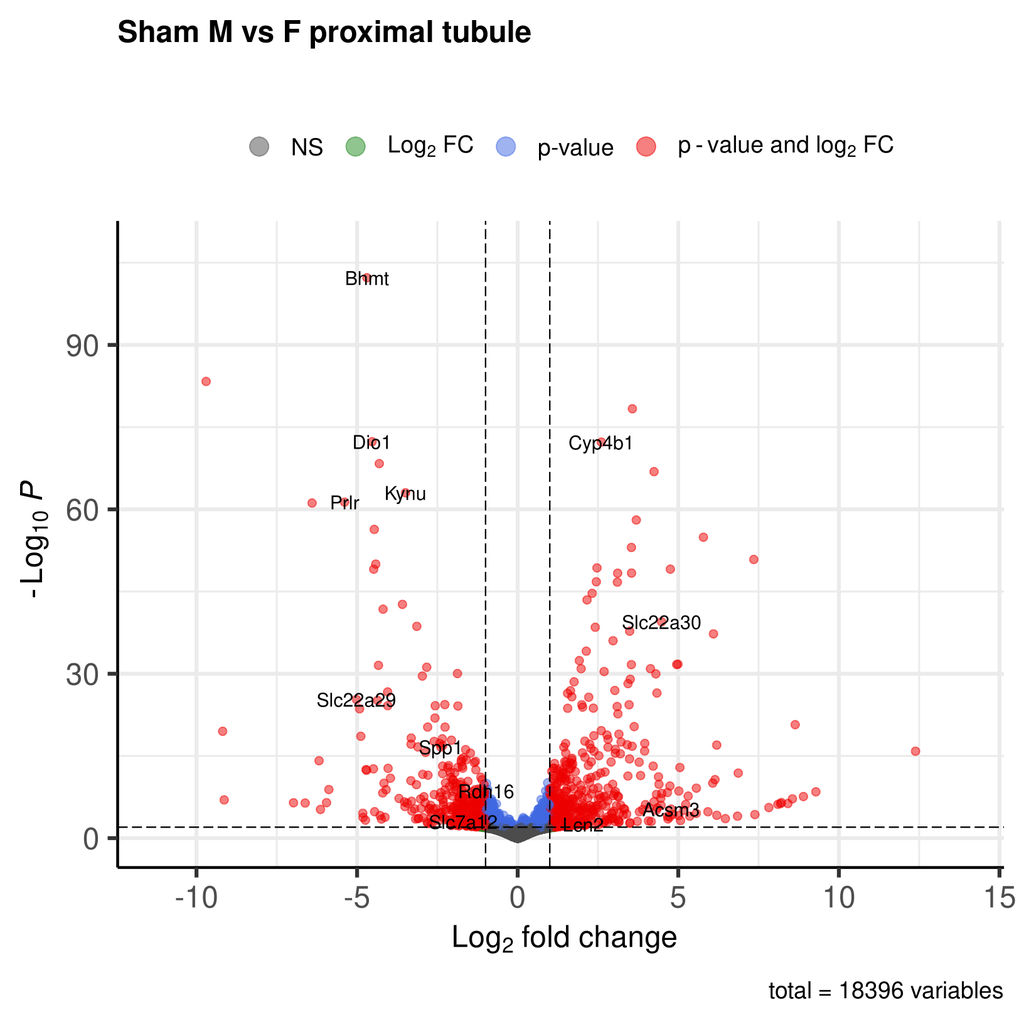

Moreover, we can reproduce the table of top 20 up-regulated gene and top 20 down-regulated genes. Genes are not in the same order but most of the genes are present in the tables made by the paper and the reproduced tables.

Top 20 up-regualted genes for Sham M vs F in proximal tubules

|  | baseMean | log2FoldChange | lfcSE | pvalue | padj |
| --- | --- | --- | --- | --- | --- |
| Gvin1 | 209.516896 | 12.386714 | 3.1595771 | 0.0000000 | 0.0000000 |
| Cyp2b10 | 33.768369 | 9.284126 | 2.9310935 | 0.0000000 | 0.0000002 |
| Styk1 | 20.931666 | 8.896203 | 2.9150947 | 0.0000000 | 0.0000014 |
| Gstp3 | 203.503586 | 8.639871 | 0.8943334 | 0.0000000 | 0.0000000 |
| Gm25682 | 22.537771 | 8.554373 | 2.8839031 | 0.0000001 | 0.0000034 |
| Adh6b | 21.557144 | 8.412900 | 2.9537694 | 0.0000005 | 0.0000204 |
| Adamts4 | 18.781799 | 8.212875 | 2.8805438 | 0.0000003 | 0.0000139 |
| Gm32687 | 19.088938 | 8.181785 | 2.9007416 | 0.0000005 | 0.0000211 |
| Smoc1 | 18.211938 | 8.100307 | 2.8972958 | 0.0000007 | 0.0000272 |
| Mpped1 | 19.884165 | 7.819972 | 2.9216013 | 0.0000026 | 0.0000895 |
| Cyp4f15 | 9.875291 | 7.385301 | 3.1291005 | 0.0000498 | 0.0012166 |
| Kdm5d | 466.646382 | 7.351689 | 0.4946203 | 0.0000000 | 0.0000000 |
| Lhx2 | 63.283927 | 6.866651 | 0.9830355 | 0.0000000 | 0.0000000 |
| Gm5717 | 10.852515 | 6.844904 | 3.0632884 | 0.0000993 | 0.0022028 |
| Shoc1 | 9.512546 | 6.466324 | 3.1750888 | 0.0002766 | 0.0053112 |
| Gm5901 | 14.451510 | 6.199917 | 2.1147690 | 0.0000680 | 0.0015959 |
| Apoh | 231.340121 | 6.197035 | 0.7484926 | 0.0000000 | 0.0000000 |
| Cyp2d9 | 4291.393664 | 6.144710 | 0.9884989 | 0.0000000 | 0.0000000 |
| C4a | 213.140322 | 6.095871 | 0.4864581 | 0.0000000 | 0.0000000 |
| Ugt2b37 | 5850.712906 | 6.072872 | 1.0151502 | 0.0000000 | 0.0000000 |

Top 20 down-regualted genes for Sham M vs F in proximal tubules

|  | baseMean | log2FoldChange | lfcSE | pvalue | padj |
| --- | --- | --- | --- | --- | --- |
| Ugt1a2 | 40295.88856 | -9.699934 | 0.5051555 | 0.0000000 | 0.0000000 |
| Atp13a4 | 272.86279 | -9.184994 | 1.0066693 | 0.0000000 | 0.0000000 |
| Cplx3 | 34.29329 | -9.138092 | 3.1095573 | 0.0000001 | 0.0000051 |
| Slc17a2 | 39.31561 | -6.979050 | 1.6049202 | 0.0000004 | 0.0000152 |
| 9230105E05Rik | 26.87674 | -6.616765 | 1.5012455 | 0.0000004 | 0.0000167 |
| Hdc | 1795.47933 | -6.400977 | 0.3906436 | 0.0000000 | 0.0000000 |
| Gm6135 | 82.95000 | -6.183302 | 0.8084892 | 0.0000000 | 0.0000000 |
| E330021D16Rik | 19.76658 | -6.139377 | 1.6054827 | 0.0000058 | 0.0001807 |
| Clic6 | 29.85099 | -5.951132 | 1.2710168 | 0.0000003 | 0.0000146 |
| Fabp1 | 70.91929 | -5.878877 | 1.0254661 | 0.0000000 | 0.0000001 |
| Prlr | 2218.83707 | -5.388257 | 0.3286057 | 0.0000000 | 0.0000000 |
| Slc22a29 | 2206.41897 | -5.019141 | 0.4900724 | 0.0000000 | 0.0000000 |
| Ugt1a1 | 497.18815 | -4.922004 | 0.5019341 | 0.0000000 | 0.0000000 |
| 9030619P08Rik | 288.00142 | -4.882742 | 0.5601850 | 0.0000000 | 0.0000000 |
| Adamtsl3 | 25.64860 | -4.821928 | 1.4137195 | 0.0000288 | 0.0007570 |
| Pjvk | 19.16777 | -4.814201 | 1.6592999 | 0.0001718 | 0.0035373 |
| Tlr13 | 11.10873 | -4.739770 | 1.9269759 | 0.0005228 | 0.0089332 |
| Akr1c20 | 313.46090 | -4.721155 | 0.6818532 | 0.0000000 | 0.0000000 |
| Camk1g | 75.83904 | -4.703375 | 0.6869017 | 0.0000000 | 0.0000000 |
| Bhmt | 1685.55007 | -4.693057 | 0.2191745 | 0.0000000 | 0.0000000 |

To further the study’s results, GSEA of the results could be performed using $log_2(FoldChange)$ to rank the genes. In this analysis, we can see that the ribosomal and metabolic pathways are downregualted in male proximal tubule cells compared to female data.

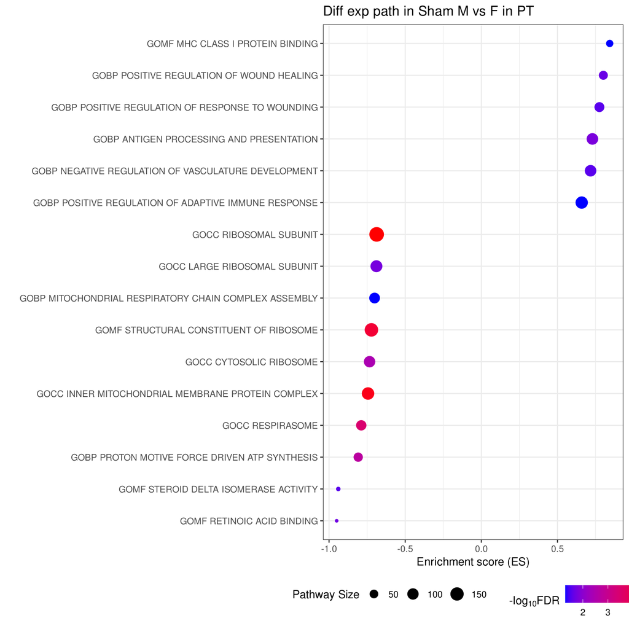

Using RNA-Seq data we can confirm that the expression of some genes are consistent:

- Higher in M: `Csnk1e, Cyp2b10, Cyp7b1, Lcn2`
- Higher in F: `Slc7a12`

But the gene expression of `Havcr1` and `Krt20` are not significant. This is most likely due to the limitations of RNA-Seq for high percision quantification of a low number of genes.

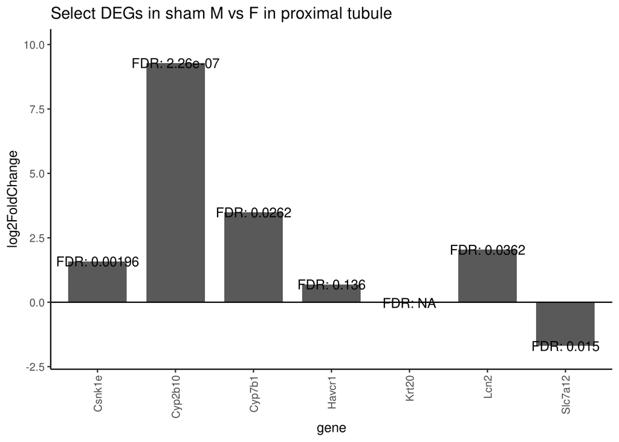

Looking at the CPM values, we can see that the differnce between the samples is not very clear.

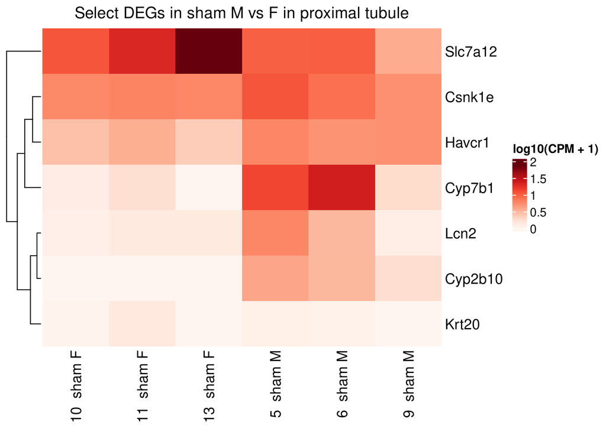

### Endothelial cells

Like the tubular tissue, overall structure of the volcano plot reproduced is similar with the volcano plot on `Figure 4 B`. More importantly, like last time, most of the genes are in the correct direction.

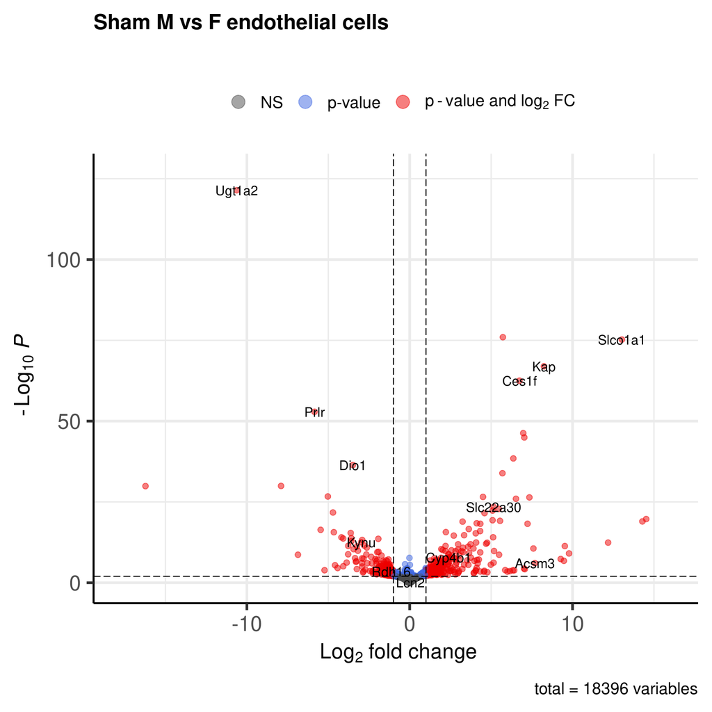

Like the data in proximal tubule, we can reproduce the table of top 20 up-regulated gene and top 20 down-regulated genes. Genes are not in the same order but most of the genes are present in the tables made by the paper and the reproduced tables. Xist is a notable exception to the trend as it appears at the top with $log_2(FoldChange)$ of -16.23. However, this can be due to differences in the package version, software versions, and operating systems used.

Top 20 up-regualted genes for Sham M vs F in endothelial tissue

|  | baseMean | log2FoldChange | lfcSE | pvalue | padj |
| --- | --- | --- | --- | --- | --- |
| Ddx3y | 1399.74482 | 14.522999 | 3.2970856 | 0.00e+00 | 0.0000000 |
| Eif2s3y | 1138.59970 | 14.289210 | 3.2775178 | 0.00e+00 | 0.0000000 |
| Slco1a1 | 19781.82551 | 13.032917 | 0.7041683 | 0.00e+00 | 0.0000000 |
| Apoh | 336.28222 | 12.184580 | 3.1609342 | 0.00e+00 | 0.0000000 |
| Cntnap5a | 76.70351 | 9.784955 | 2.8880154 | 0.00e+00 | 0.0000002 |
| Cyp2j13 | 13302.14182 | 9.526656 | 1.5423851 | 0.00e+00 | 0.0000000 |
| Ct55 | 72.67259 | 9.467904 | 3.0766477 | 2.00e-07 | 0.0000239 |
| Col19a1 | 64.08213 | 9.273538 | 2.9432317 | 0.00e+00 | 0.0000074 |
| Kap | 375059.32344 | 8.243256 | 0.4802790 | 0.00e+00 | 0.0000000 |
| Acsm3 | 8828.18586 | 7.683407 | 2.0335327 | 9.00e-07 | 0.0001051 |
| Gstp3 | 146.94287 | 7.597148 | 1.1818013 | 0.00e+00 | 0.0000000 |
| Cyp2d9 | 3025.23784 | 7.350711 | 0.7051355 | 0.00e+00 | 0.0000000 |
| C4a | 138.65708 | 7.235591 | 0.8148632 | 0.00e+00 | 0.0000000 |
| Adh6b | 20.98414 | 7.066198 | 3.0463007 | 6.41e-05 | 0.0044191 |
| Pzp | 3422.67813 | 7.039059 | 0.5093433 | 0.00e+00 | 0.0000000 |
| Gm25682 | 19.39111 | 7.023758 | 2.9182001 | 3.84e-05 | 0.0028922 |
| Akr1c14 | 9625.94474 | 6.971190 | 0.4929507 | 0.00e+00 | 0.0000000 |
| Ces1f | 18350.63161 | 6.739992 | 0.4077354 | 0.00e+00 | 0.0000000 |
| Ugt2b37 | 4442.63647 | 6.525472 | 0.6319280 | 0.00e+00 | 0.0000000 |
| H2bc13 | 14.93939 | 6.418872 | 2.9590045 | 1.39e-04 | 0.0086004 |

Top 20 down-regualted genes for Sham M vs F in endothelial tissue

|  | baseMean | log2FoldChange | lfcSE | pvalue | padj |
| --- | --- | --- | --- | --- | --- |
| Xist | 1898.80502 | -16.227511 | 3.6234510 | 0.0000000 | 0.0000000 |
| Ugt1a2 | 53756.54077 | -10.624539 | 0.4516794 | 0.0000000 | 0.0000000 |
| Atp13a4 | 273.75201 | -7.902553 | 0.6906440 | 0.0000000 | 0.0000000 |
| Fabp1 | 67.07310 | -6.865311 | 1.2143997 | 0.0000000 | 0.0000004 |
| Prlr | 3016.25622 | -5.844878 | 0.3833620 | 0.0000000 | 0.0000000 |
| Hdc | 1622.16134 | -5.469606 | 0.6740648 | 0.0000000 | 0.0000000 |
| Sstr3 | 10.85854 | -5.230833 | 1.6902681 | 0.0001322 | 0.0082335 |
| Akr1c20 | 362.64970 | -5.029373 | 0.4743439 | 0.0000000 | 0.0000000 |
| Cyp4a14 | 38095.45614 | -4.713228 | 0.4959729 | 0.0000000 | 0.0000000 |
| Hells | 165.00473 | -4.661029 | 0.5930816 | 0.0000000 | 0.0000000 |
| Chil3 | 60.55733 | -4.584805 | 1.1800711 | 0.0000038 | 0.0003791 |
| Efcab5 | 74.67451 | -4.428631 | 1.3121688 | 0.0000276 | 0.0022060 |
| Slc22a29 | 1833.79192 | -4.191719 | 0.5646353 | 0.0000000 | 0.0000000 |
| Bhmt | 1833.97743 | -4.085028 | 0.5583601 | 0.0000000 | 0.0000000 |
| Mab21l4 | 109.98005 | -4.081007 | 1.0714994 | 0.0000077 | 0.0007119 |
| Trpm2 | 51.28290 | -3.871958 | 0.8962023 | 0.0000006 | 0.0000756 |
| Slc22a27 | 206.98134 | -3.780947 | 0.6759652 | 0.0000000 | 0.0000003 |
| Ugt2b34 | 367.18163 | -3.777787 | 0.5757270 | 0.0000000 | 0.0000000 |
| Gsta2 | 4495.16218 | -3.622599 | 0.4629599 | 0.0000000 | 0.0000000 |
| Cpn1 | 233.90988 | -3.585757 | 0.5093922 | 0.0000000 | 0.0000000 |

To further the study’s results, GSEA of the results could be performed using $log_2(FoldChange)$ to rank the genes. In endothelial cells, we can observe that there are no significantly differentially experssed genes using FDR < 0.05 as threshold. If we use P value, we can see that we have positive enrichment of immunity and metbaolic pathways pathways, and negative enrichment of of differentiation pathways in male versus female endothelial cells.

**This supports the hypothesis that there are significant sexual dysmorphism in kidney tissue in mice and the effect is more distinctly observed in proximal tubules than endothelial cells.**

Diff exp path in Sham M vs F in endothelial tissue

| pathway | pval | padj | log2err | ES | NES | size |
| --- | --- | --- | --- | --- | --- | --- |
| GOBP ANTIGEN PROCESSING AND PRESENTATION | 0.0000669 | 0.3216489 | 0.5384341 | 0.8165738 | 1.909981 | 107 |
| GOBP ANTIGEN PROCESSING AND PRESENTATION OF PEPTIDE ANTIGEN | 0.0000994 | 0.3216489 | 0.5384341 | 0.8569574 | 1.873883 | 62 |
| GOMF OLIGOPEPTIDE BINDING | 0.0000754 | 0.3216489 | 0.5384341 | -0.9165380 | -1.920669 | 18 |
| GOMF LIPOPROTEIN LIPASE ACTIVATOR ACTIVITY | 0.0001478 | 0.3587718 | 0.5188481 | 0.9979336 | 1.523525 | 3 |
| GOBP SPONGIOTROPHOBLAST DIFFERENTIATION | 0.0002404 | 0.4296103 | 0.5188481 | -0.9912316 | -1.599597 | 4 |
| GOMF SOMATOSTATIN RECEPTOR ACTIVITY | 0.0003097 | 0.4296103 | 0.4984931 | -0.9900094 | -1.597625 | 4 |
| GOMF STEROID DELTA ISOMERASE ACTIVITY | 0.0002738 | 0.4296103 | 0.4984931 | -0.9543370 | -1.887443 | 13 |
| GOBP ANTIGEN PROCESSING AND PRESENTATION OF EXOGENOUS ANTIGEN | 0.0007823 | 0.4354008 | 0.4772708 | 0.8729210 | 1.805495 | 36 |
| GOBP ANTIGEN PROCESSING AND PRESENTATION OF EXOGENOUS PEPTIDE ANTIGEN | 0.0006920 | 0.4354008 | 0.4772708 | 0.9047142 | 1.865626 | 30 |
| GOBP AROMATIC AMINO ACID FAMILY CATABOLIC PROCESS | 0.0016802 | 0.4354008 | 0.4550599 | -0.9034783 | -1.836634 | 14 |
| GOBP CELLULAR RESPONSE TO PURINE CONTAINING COMPOUND | 0.0015117 | 0.4354008 | 0.4550599 | -0.9229169 | -1.784199 | 10 |
| GOBP CELL DIFFERENTIATION INVOLVED IN EMBRYONIC PLACENTA DEVELOPMENT | 0.0006210 | 0.4354008 | 0.4772708 | -0.8781160 | -1.950219 | 29 |
| GOBP EMBRYONIC PLACENTA DEVELOPMENT | 0.0015230 | 0.4354008 | 0.4550599 | -0.6985988 | -1.876287 | 106 |
| GOBP ETHANOL METABOLIC PROCESS | 0.0009302 | 0.4354008 | 0.4772708 | 0.9686515 | 1.764892 | 9 |
| GOBP FATTY ACID ELONGATION SATURATED FATTY ACID | 0.0016930 | 0.4354008 | 0.4550599 | -0.9695292 | -1.702287 | 6 |

## Comparison of IRI mices

### Proximal tubules

The overall structure of the volcano plot reproduced is similiar with the volcano plot on `Figure 6 A`. Majority of the genes highlighted in the volcano plot by the researchers are also significantly differentially expressed in the reproduced volcano plot and are in the same direction.

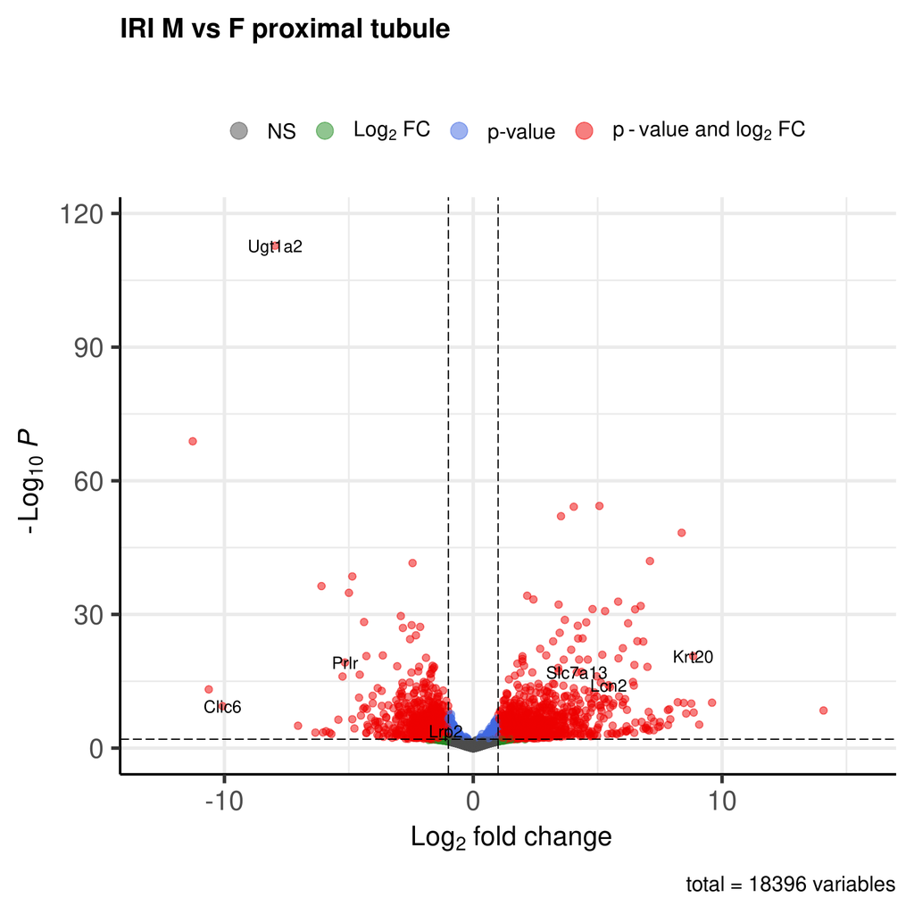

Moreover, we can reproduce the table of top 20 up-regulated gene and top 20 down-regulated genes. Genes are not in the same order but most of the genes are present in the tables made by the paper and the reproduced tables.

Top 20 up-regualted genes for IRI M vs F in proximal tubules

|  | baseMean | log2FoldChange | lfcSE | pvalue | padj |
| --- | --- | --- | --- | --- | --- |
| Cyp2b10 | 869.93299 | 14.078841 | 3.8962477 | 0.00e+00 | 0.0000002 |
| Cntnap5a | 40.77300 | 9.596453 | 2.8899244 | 0.00e+00 | 0.0000000 |
| Sult1e1 | 362.23273 | 9.081867 | 2.4340844 | 5.40e-06 | 0.0001263 |
| Ccl20 | 28.04489 | 8.859901 | 2.8800532 | 0.00e+00 | 0.0000005 |
| Krt20 | 8492.80605 | 8.839083 | 0.9633190 | 0.00e+00 | 0.0000000 |
| 4930579F01Rik | 146.07137 | 8.762757 | 1.3728198 | 0.00e+00 | 0.0000000 |
| Mpped1 | 24.16767 | 8.556429 | 2.8320392 | 0.00e+00 | 0.0000008 |
| Fosl1 | 1276.94551 | 8.460107 | 1.4129597 | 0.00e+00 | 0.0000000 |
| Acsm3 | 14393.43534 | 8.376116 | 0.5769186 | 0.00e+00 | 0.0000000 |
| Slco1a1 | 11752.05265 | 8.217929 | 1.3577068 | 0.00e+00 | 0.0000000 |
| Gm10409 | 16.49381 | 7.920786 | 2.8133419 | 3.00e-07 | 0.0000115 |
| Slc13a5 | 59.88707 | 7.879696 | 1.4918266 | 0.00e+00 | 0.0000001 |
| Fgf21 | 17.67660 | 7.828587 | 3.0006472 | 6.70e-06 | 0.0001491 |
| Serpina3m | 100.42264 | 7.823040 | 1.3782037 | 0.00e+00 | 0.0000002 |
| Scart2 | 16.34288 | 7.504552 | 2.9641038 | 1.14e-05 | 0.0002375 |
| 1700001F09Rik | 13.19659 | 7.503857 | 2.7914192 | 1.40e-06 | 0.0000401 |
| Gml | 16.16487 | 7.440232 | 3.0011737 | 1.89e-05 | 0.0003580 |
| Eif2s3y | 1501.87780 | 7.268700 | 1.7816703 | 1.10e-06 | 0.0000330 |
| Sh2d6 | 13.96067 | 7.254881 | 3.2055259 | 9.92e-05 | 0.0014088 |
| Slc6a19os | 770.43093 | 7.156254 | 1.5715039 | 2.00e-07 | 0.0000058 |

Top 20 down-regualted genes for IRI M vs F in proximal tubules

|  | baseMean | log2FoldChange | lfcSE | pvalue | padj |
| --- | --- | --- | --- | --- | --- |
| Xist | 1923.566185 | -11.274193 | 0.6347104 | 0.0000000 | 0.0000000 |
| Serpina6 | 76.429936 | -10.628786 | 3.0440593 | 0.0000000 | 0.0000000 |
| Clic6 | 52.022459 | -10.073450 | 3.1069018 | 0.0000000 | 0.0000000 |
| Ugt1a2 | 31413.766763 | -7.965651 | 0.3536989 | 0.0000000 | 0.0000000 |
| Pjvk | 13.656484 | -7.043028 | 2.8555631 | 0.0000098 | 0.0002085 |
| Scml2 | 9.836180 | -6.344569 | 3.2032141 | 0.0003320 | 0.0036990 |
| Serpina1f | 496.447679 | -6.099788 | 0.4871553 | 0.0000000 | 0.0000000 |
| Gm14444 | 8.079778 | -6.038119 | 3.0402723 | 0.0003161 | 0.0035627 |
| Gm29811 | 6.691698 | -5.916800 | 2.8483466 | 0.0001690 | 0.0021488 |
| Gm19211 | 6.630120 | -5.775089 | 2.9398667 | 0.0003294 | 0.0036860 |
| Ky | 7.249836 | -5.702076 | 3.1614719 | 0.0006889 | 0.0065725 |
| Gm52805 | 10.909802 | -5.422333 | 1.2088414 | 0.0000004 | 0.0000139 |
| Slc7a12 | 667.271374 | -5.253315 | 0.6589611 | 0.0000000 | 0.0000000 |
| Prlr | 1913.750438 | -5.155134 | 0.5838808 | 0.0000000 | 0.0000000 |
| Slc22a13 | 767.614241 | -4.996586 | 0.4082801 | 0.0000000 | 0.0000000 |
| Bhmt | 1107.063809 | -4.861366 | 0.3768226 | 0.0000000 | 0.0000000 |
| Hsd17b6 | 44.820740 | -4.860724 | 1.0835566 | 0.0000003 | 0.0000114 |
| Gm2814 | 14.580283 | -4.774741 | 1.2903037 | 0.0000391 | 0.0006682 |
| Kcnab2 | 116.212696 | -4.589831 | 0.6964025 | 0.0000000 | 0.0000000 |
| Akr1c20 | 291.570591 | -4.563126 | 0.5654214 | 0.0000000 | 0.0000000 |

To further the study’s results, GSEA of the results could be performed using $log_2(FoldChange)$ to rank the genes. There are key observations that support researcher’s hypotehsis:

- Ion transport, voltage gated channels, and Cation transport pathways are down regulated in male IRI (support cationic transporter over expression in females)
- Oxidative phosphorylation is down regulated in male IRI
- Up regulation of starvation, stress, and kinase activity (supports up regulation of immunity pathways in male vs female IRI)

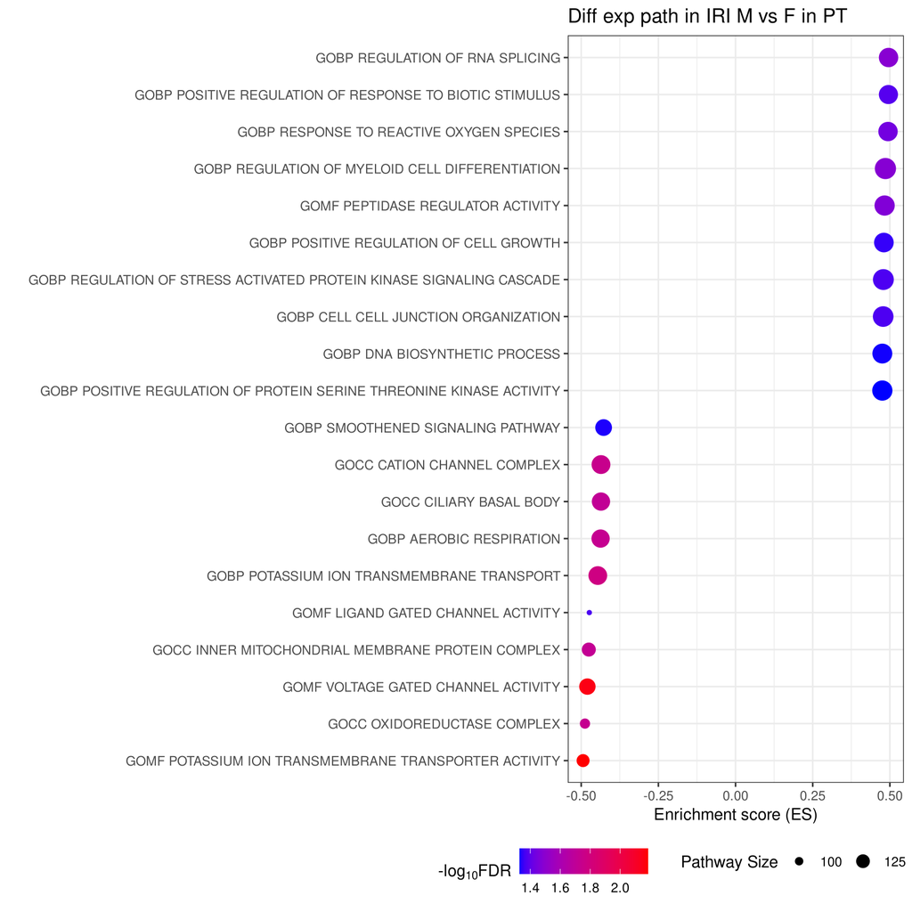

> NOTE: we could not find information from the `Havcr` gene. It is possible that the gene symbol has changed or the ensembel ID was not present.

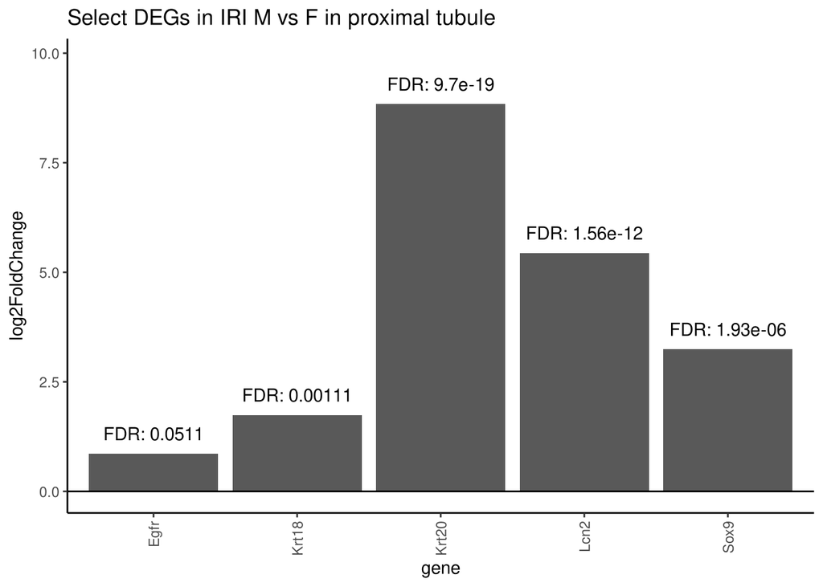

Even using the raw count data we can confirm that these genes are over expressed in the male mice versus female mice. However the clustering of the heatmap is successful at distinguishing male and female IRI samples.

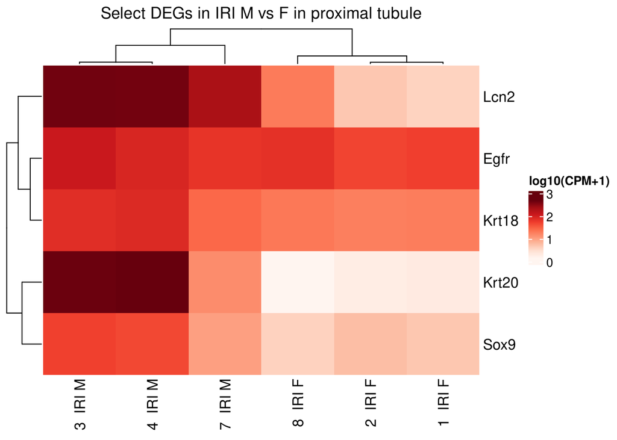

The study has claimed that some key genes are downregualted in male IRI versus female IRI which were only partially reproduced. `Lrp2` gene is significantly underexpressed in M vs F IRI mice, however, `Bcl2` is not.

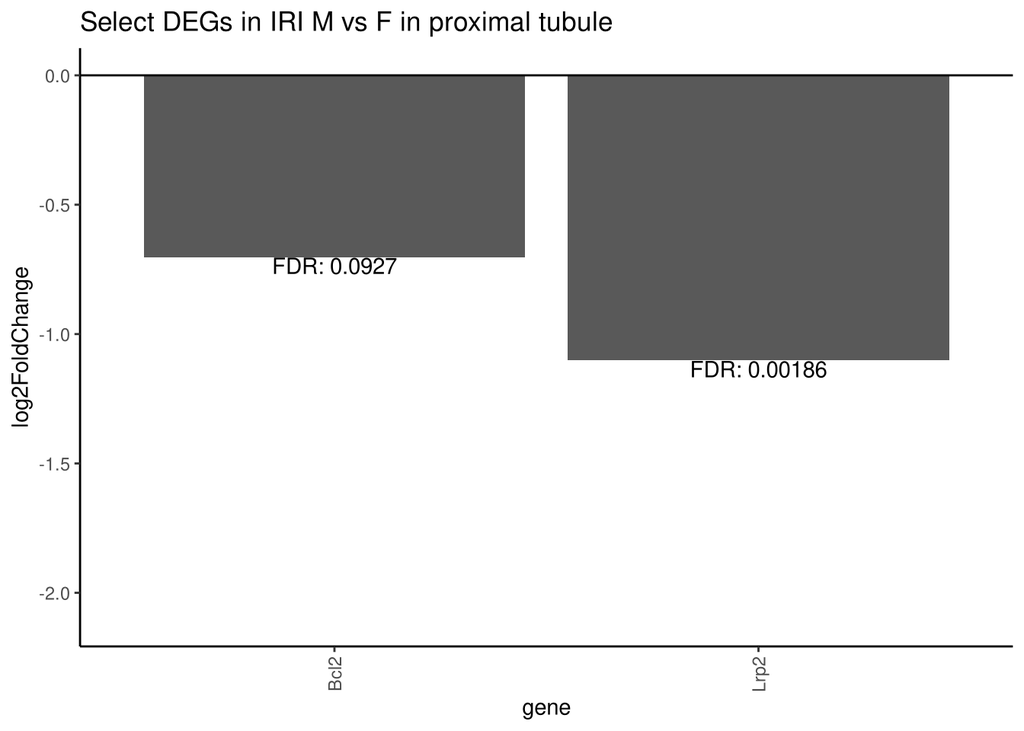

In this heatmap, the clustering cannot fully distinguishe between M vs F.

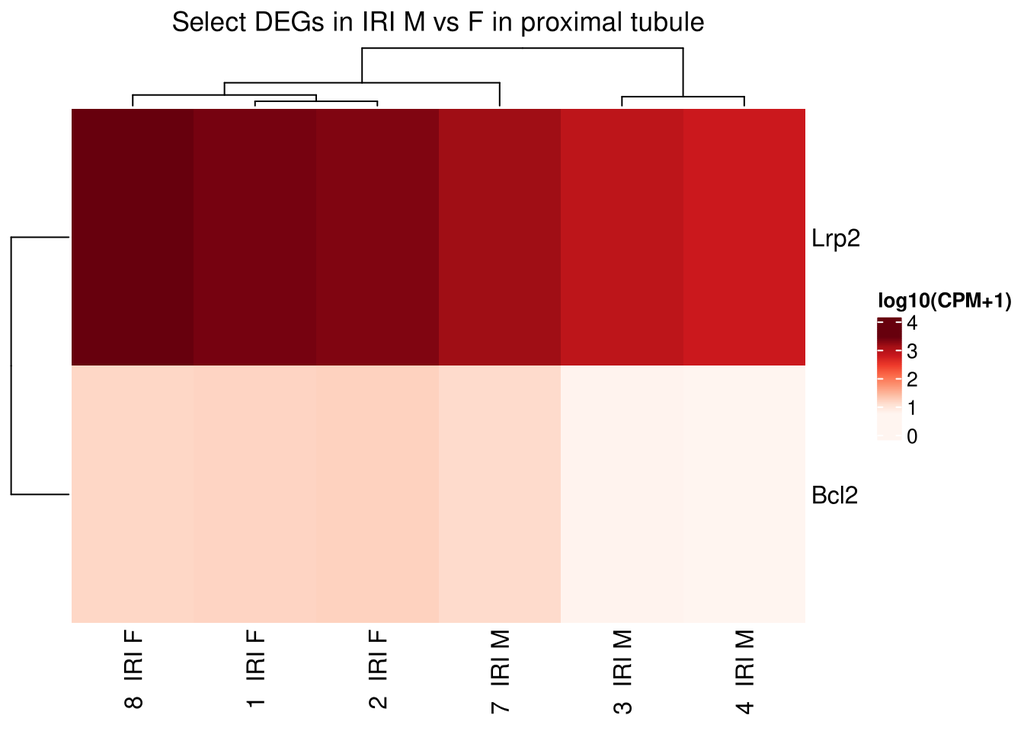

### Endothelial cells

Like the tubular tissue, overall structure of the volcano plot reproduced is similar with the volcano plot on `Figure 4 B`. Like proximal tubule samples, majority of the genes highlighted in the volcano plot by the researchers are also significantly differentially expressed in the reproduced volcano plot and are in the same direction.

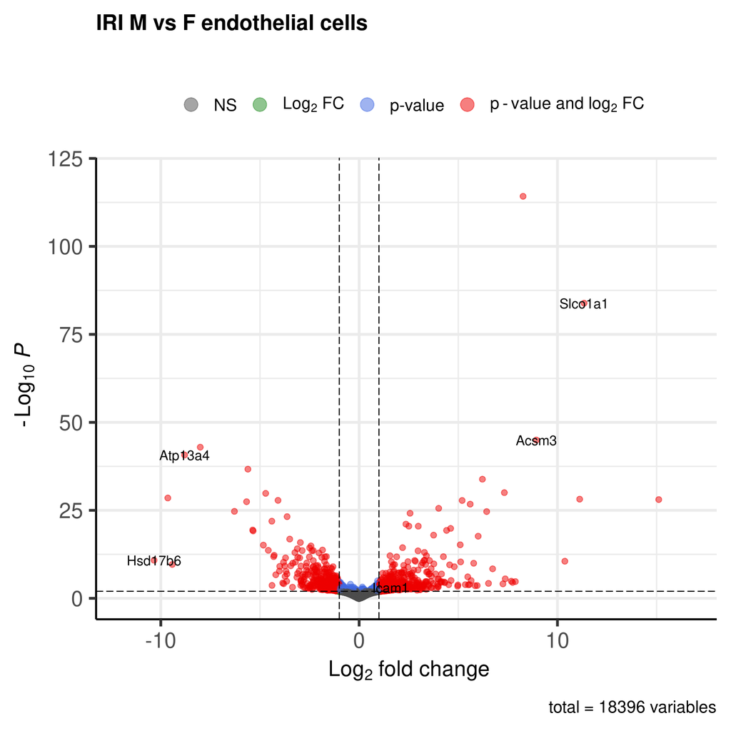

Like the data in proximal tubule, we can reproduce the table of top 20 up-regulated gene and top 20 down-regulated genes. Genes are not in the same order but most of the genes are present in the tables made by the paper and the reproduced tables.

Top 20 up-regualted genes for IRI M vs F in endothelial tissue

|  | baseMean | log2FoldChange | lfcSE | pvalue | padj |
| --- | --- | --- | --- | --- | --- |
| Eif2s3y | 1.247454e+03 | 15.107835 | 3.3415780 | 0.0000000 | 0.0000000 |
| Slco1a1 | 8.024308e+03 | 11.344114 | 0.5806795 | 0.0000000 | 0.0000000 |
| Ddx3y | 1.576490e+03 | 11.119932 | 0.9920513 | 0.0000000 | 0.0000000 |
| Lilrb4a | 7.022654e+01 | 10.372352 | 3.0181058 | 0.0000000 | 0.0000000 |
| Acsm3 | 7.370177e+03 | 8.935546 | 0.6465411 | 0.0000000 | 0.0000000 |
| Cyp2j13 | 5.707315e+03 | 8.266178 | 0.3656363 | 0.0000000 | 0.0000000 |
| Adh6b | 2.141579e+01 | 7.878701 | 3.1310410 | 0.0000177 | 0.0011430 |
| Cyp2b10 | 1.874232e+02 | 7.735726 | 2.4167073 | 0.0000303 | 0.0017832 |
| Cntnap5a | 1.840610e+01 | 7.674285 | 3.0378639 | 0.0000137 | 0.0009439 |
| 4930579F01Rik | 3.544998e+01 | 7.368084 | 1.8763617 | 0.0000029 | 0.0002481 |
| Kdm5d | 3.912946e+02 | 7.322795 | 0.6470370 | 0.0000000 | 0.0000000 |
| Adora3 | 1.522250e+01 | 7.250988 | 3.1656723 | 0.0000784 | 0.0039119 |
| Lhx2 | 6.319262e+01 | 6.731479 | 1.1996462 | 0.0000000 | 0.0000007 |
| Popdc3 | 1.042832e+01 | 6.523333 | 2.8644757 | 0.0000572 | 0.0030239 |
| Pzp | 1.437252e+03 | 6.430133 | 0.6356779 | 0.0000000 | 0.0000000 |
| Kap | 1.464939e+05 | 6.215641 | 0.5010508 | 0.0000000 | 0.0000000 |
| Vgf | 2.169962e+02 | 6.002637 | 0.7127716 | 0.0000000 | 0.0000000 |
| Nppb | 7.587891e+00 | 5.952200 | 2.9232252 | 0.0002366 | 0.0089325 |
| Gm7935 | 7.197766e+00 | 5.849424 | 2.9111446 | 0.0002657 | 0.0098590 |
| Ptpn22 | 1.054766e+03 | 5.776830 | 0.9716014 | 0.0000000 | 0.0000000 |

Top 20 down-regualted genes for IRI M vs F in endothelial tissue

|  | baseMean | log2FoldChange | lfcSE | pvalue | padj |
| --- | --- | --- | --- | --- | --- |
| Hsd17b6 | 61.47254 | -10.340731 | 3.0790098 | 0.0000000 | 0.0000000 |
| Xist | 1994.73041 | -9.645583 | 0.8750777 | 0.0000000 | 0.0000000 |
| Mdrl | 35.63570 | -9.419717 | 2.9536390 | 0.0000000 | 0.0000001 |
| Atp13a4 | 536.07447 | -8.801604 | 0.6902065 | 0.0000000 | 0.0000000 |
| Ugt1a2 | 42615.11303 | -8.011283 | 0.5872638 | 0.0000000 | 0.0000000 |
| 9030619P08Rik | 229.80518 | -6.287628 | 0.6313167 | 0.0000000 | 0.0000000 |
| Slc22a27 | 200.93045 | -5.674854 | 0.5281104 | 0.0000000 | 0.0000000 |
| Bhmt | 1385.01150 | -5.608564 | 0.4471614 | 0.0000000 | 0.0000000 |
| Slc22a29 | 2074.79072 | -5.367364 | 0.6074135 | 0.0000000 | 0.0000000 |
| Prlr | 2146.71544 | -5.344375 | 0.6054939 | 0.0000000 | 0.0000000 |
| Slc22a13 | 589.25729 | -4.827851 | 0.6298490 | 0.0000000 | 0.0000000 |
| Slc22a19 | 604.17461 | -4.712411 | 0.4194083 | 0.0000000 | 0.0000000 |
| Serpina1f | 119.46847 | -4.579010 | 0.6344218 | 0.0000000 | 0.0000000 |
| Xpnpep2 | 482.16088 | -4.401176 | 0.4638449 | 0.0000000 | 0.0000000 |
| Gm6345 | 13.89091 | -4.392884 | 1.6581501 | 0.0002163 | 0.0083247 |
| Ceacam2 | 116.16107 | -4.308432 | 0.6505573 | 0.0000000 | 0.0000000 |
| Slc22a26 | 222.60362 | -4.284151 | 0.6337715 | 0.0000000 | 0.0000000 |
| Clic6 | 27.11193 | -4.202649 | 0.8987627 | 0.0000002 | 0.0000230 |
| Rdh16f2 | 9790.16238 | -4.089349 | 0.3781420 | 0.0000000 | 0.0000000 |
| Slc22a13b | 61.93904 | -4.021245 | 0.7876358 | 0.0000000 | 0.0000028 |

To further the study’s results, GSEA of the results could be performed using $log_2(FoldChange)$ to rank the genes.

This results also supports the results of the paper with key takeaways:

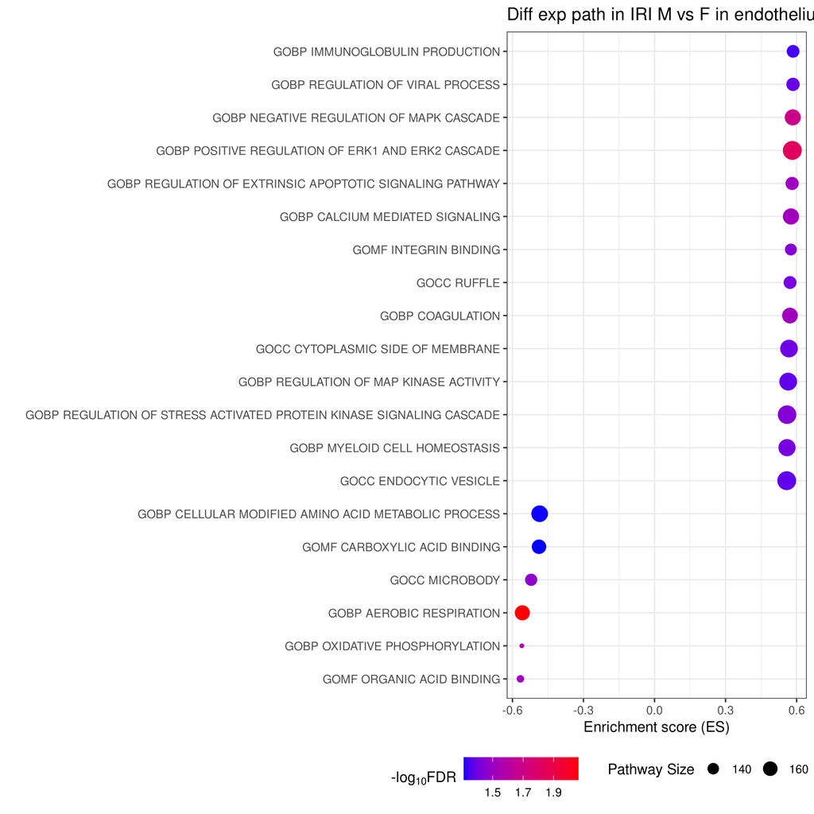

## TNF signaling

Finally researchers looked at the Z-score expression of genes relating to TNF pathway in `Figure 11 A` and `Figure 13 A`. pathway in mice to understand the genomic differences between group. They showed that male mice post-IRI have highest expression of TNF signaling pathways. Therefore, higher immune response might be involved in male susceptibility to AKI.

### Proximal tubules

For proximal tubule samples, we were not able to reproduce their heatmap. The male IRI samples could not be clustered together.

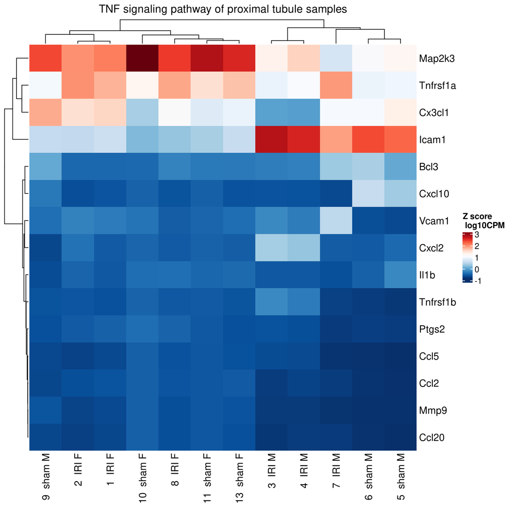

### Endothelial cells

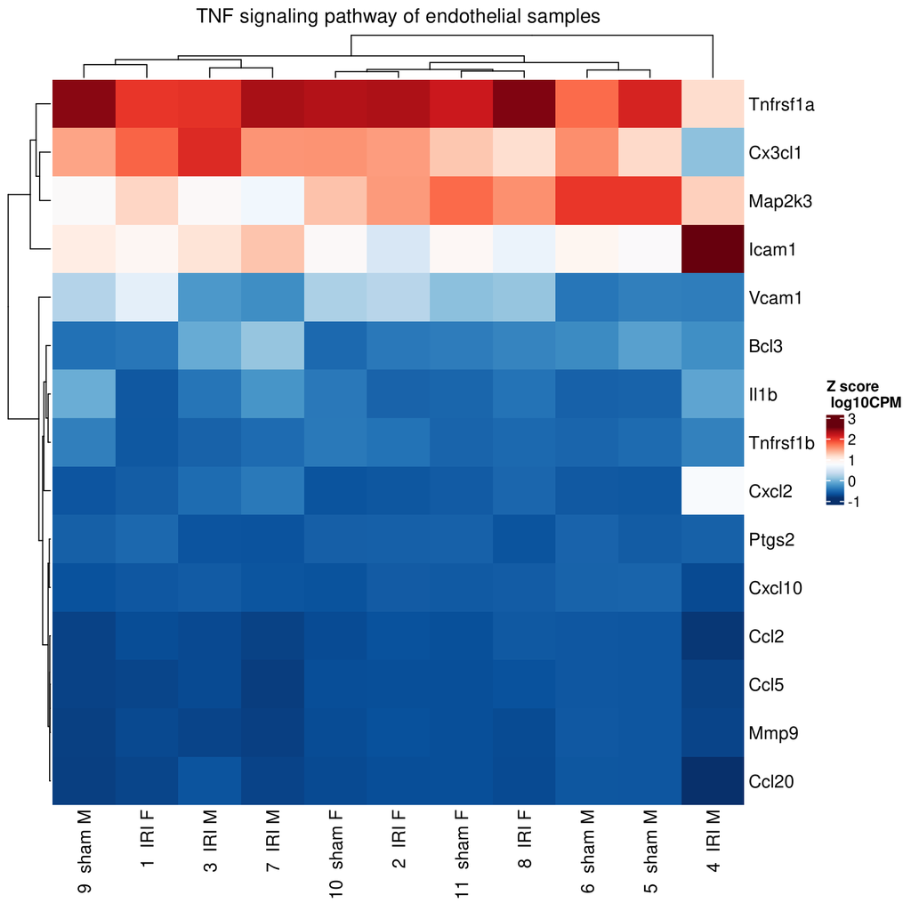

## Cytokine signaling

Finally researchers looked at the Z-score expression of genes relating to Cytokine pathway in `Figure 11 B` and `Figure 13 B` pathway in mice to understand the genomic differneces between group. They showed that male mice post-IRI have higher expression of Cytokine pathways relative to other groups. Therefore, higher immune response might be involved in male suspetibiltiy to AKI.

### Proximal tubules

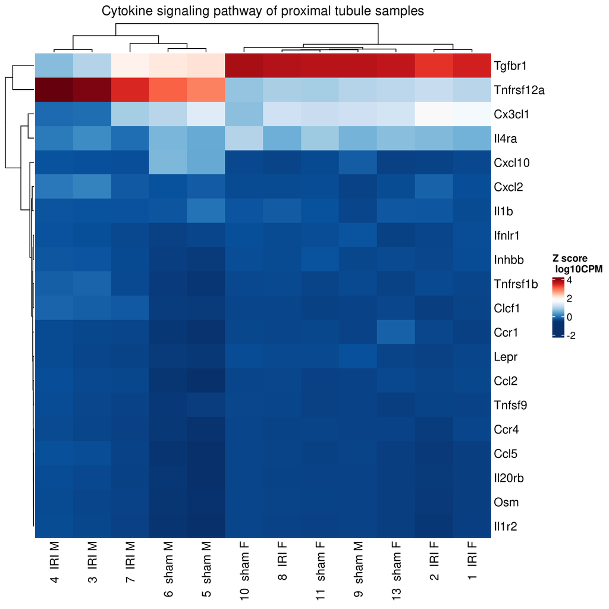

### Endothelial cells

For endothelial cells, we were not able to reproduce their heatmap. The male IRI samples could not be clustered together.

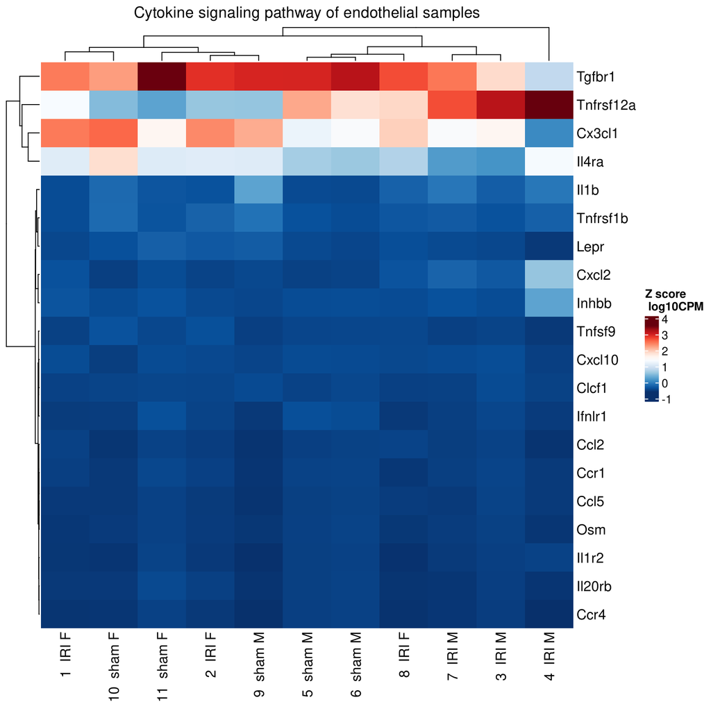

# Discussion and Conclusion

The results of the paper where reproducible majority of the times. Further gene-set enrichment analysis (GSEA) has further validated the paper’s claim that there are significant sexual dimorphism in the normal kidney and IRI patients. As seen in the volcano plots. Furthermore, we can support the paper’s claim that the differential expression in proximal tubules is more distinct that in endothelial cells.

The significantly differentially expressed genes and pathways in this study are worthy of further investigation to improve our understanding of the sex differences in IRI and to develop AKI therapeutics.

## Pathway analysis

Lastly, the positive enrichment of immunity pathways in M vs F IRI (dotplot) further supports the hypothesis that IRI condition is more severe in males than females.

The overregulation of ionic transport pathways, particularly cationic transport pathways in female IRI mice in proximal tubules, can also be a potential protective factor in females in acute kidney injury.

## TNF and Cytokine heatmaps

For key genes of TNF and Cytokine pathways, we were **not able to** reproduce the over expression of IRI male samples. However, we suspect reproducibility of the Cytokine and TNF heatmaps is possible with access to source code of the analysis.

## Code reproducibility

R script used to generate the results was claimed to be uploaded in a [github reporistory](https://github.com/retropc66/Mouse_kidney_IRI_RNA-seq). However, as of today, the last commit is a readme file mentioning that the code would be published soon.

Fortunately, the researchers provided sufficient information in the methodology section to reproduce the majority of the results accurately.

# References

Gu, Zuguang, Roland Eils, and Matthias Schlesner. 2016. “Complex Heatmaps Reveal Patterns and Correlations in Multidimensional Genomic Data.” *Bioinformatics* 32 (18): 2847–49. https://doi.org/10.1093/bioinformatics/btw313.

Korotkevich, Gennady, Vladimir Sukhov, Nikolay Budin, Boris Shpak, Maxim N. Artyomov, and Alexey Sergushichev. 2021. “Fast Gene Set Enrichment Analysis.” bioRxiv. https://doi.org/10.1101/060012.

Love, Michael I, Wolfgang Huber, and Simon Anders. 2014. “Moderated Estimation of Fold Change and Dispersion for RNA-Seq Data with DESeq2.” *Genome Biology* 15 (12): 550. https://doi.org/10.1186/s13059-014-0550-8.

Viñas, Jose L., Christopher J. Porter, Adrianna Douvris, Matthew Spence, Alex Gutsol, Joseph A. Zimpelmann, Karishma Tailor, Pearl A. Campbell, and Kevin D. Burns. 2020. “Sex Diversity in Proximal Tubule and Endothelial Gene Expression in Mice with Ischemic Acute Kidney Injury.” *Clinical Science (London, England: 1979)* 134 (14): 1887–1909. https://doi.org/10.1042/CS20200168.

Zhu, Anqi, Joseph G Ibrahim, and Michael I Love. 2019. “Heavy-Tailed Prior Distributions for Sequence Count Data: Removing the Noise and Preserving Large Differences.” *Bioinformatics* 35 (12): 2084–92. https://doi.org/10.1093/bioinformatics/bty895.

# File generation date and environment

File generation timestamp: Tue Mar 14 02:15:35 2023